# Untitled

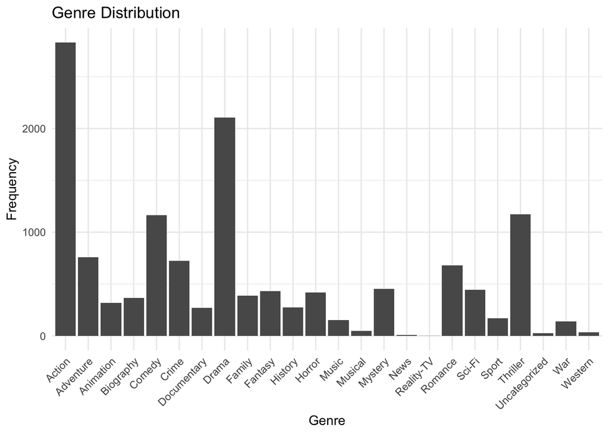

```r
library(ggplot2)
ggplot(as.data.frame(genre_freq), aes(x = split_genres, y = Freq)) +
  geom_bar(stat = "identity") +
  theme_minimal() +
  labs(title = "Genre Distribution", x = "Genre", y = "Frequency") +
  theme(axis.text.x = element_text(angle = 45, hjust = 1))
```

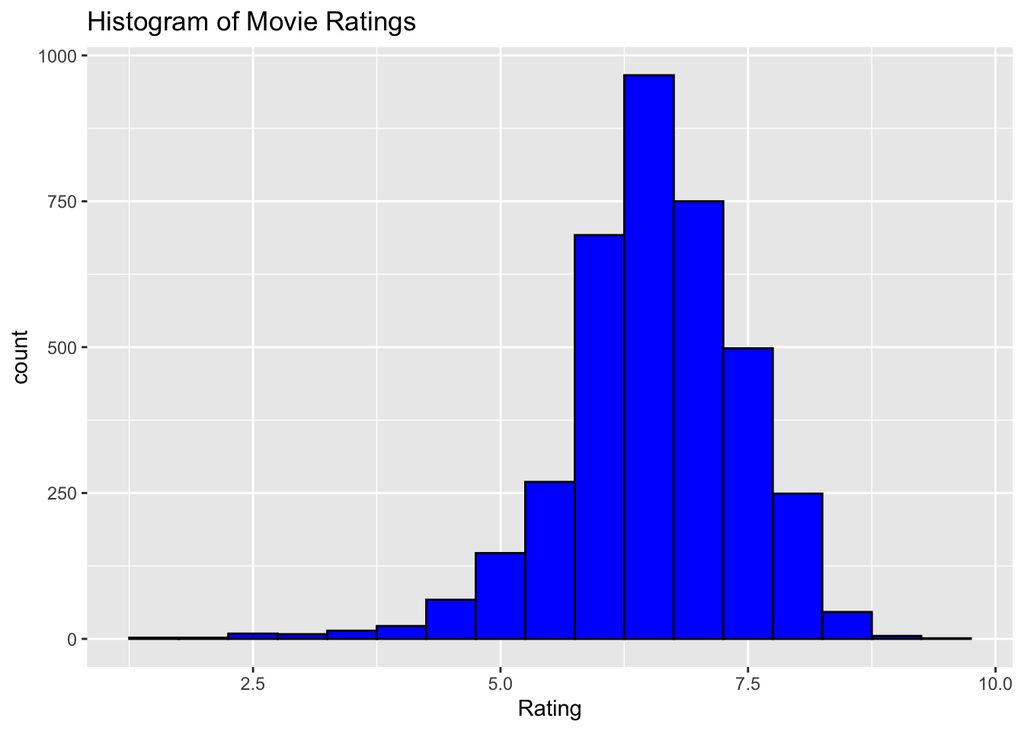

```r
filtered_data <- data[data$Runtime > 0, ]

ggplot(filtered_data, aes(x=Rating)) + geom_histogram(binwidth=0.5, fill="blue", color="black") + ggtitle("Histogram of Movie Ratings")
```

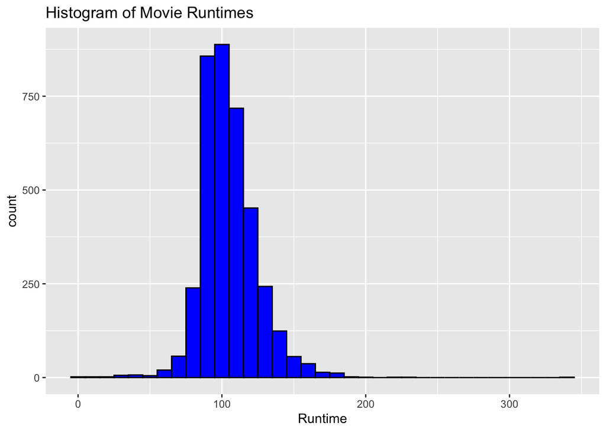

```r
ggplot(filtered_data, aes(x=Runtime)) + geom_histogram(binwidth=10, fill="blue", color="black") + ggtitle("Histogram of Movie Runtimes")
```

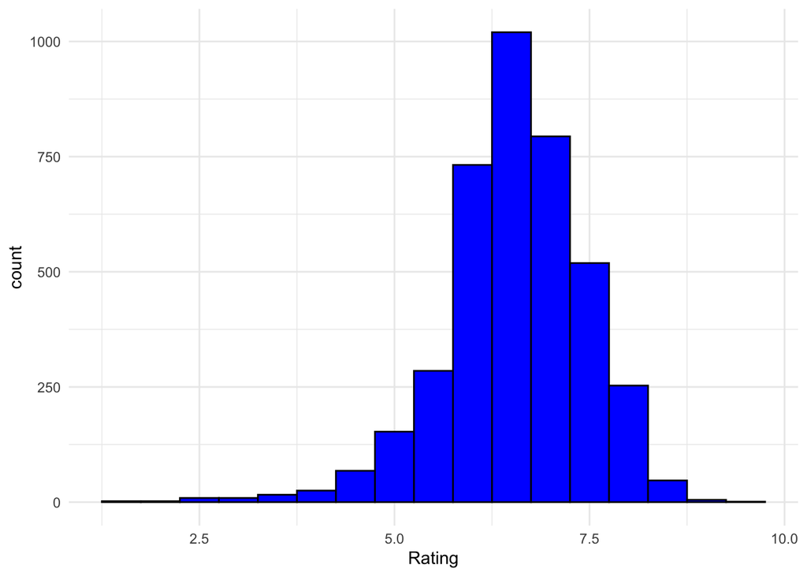

```r
ggplot(data, aes(Rating)) + geom_histogram(binwidth=0.5, fill="blue", color="black") + theme_minimal()
```

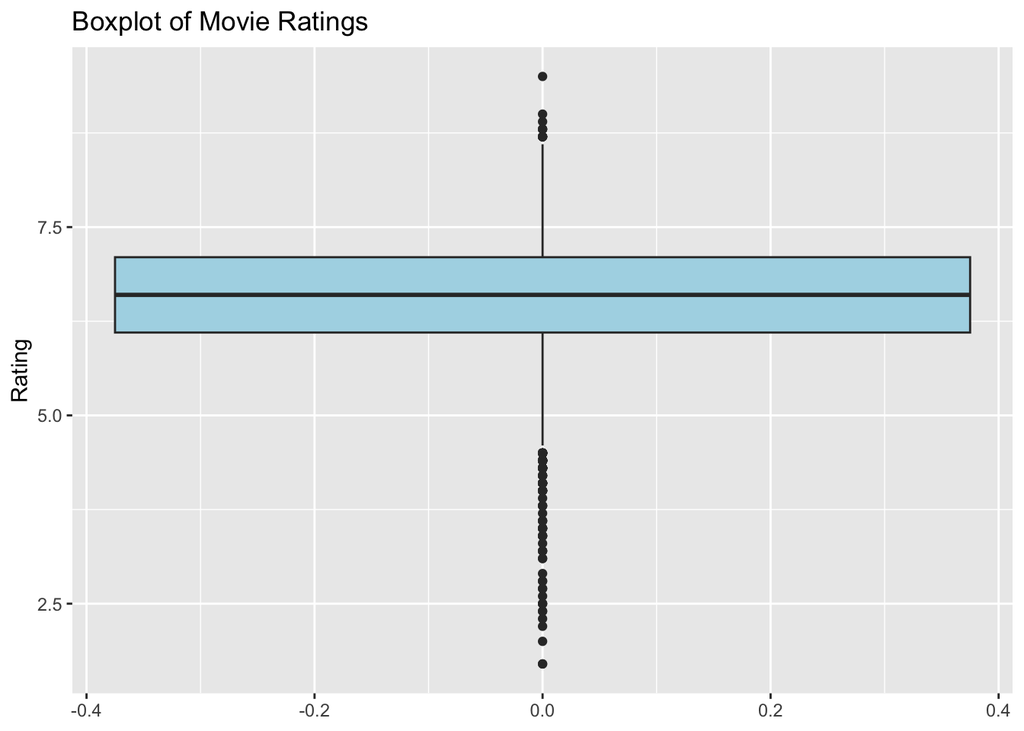

```r
ggplot(filtered_data, aes(y=Rating)) + geom_boxplot(fill="lightblue") + ggtitle("Boxplot of Movie Ratings")
```

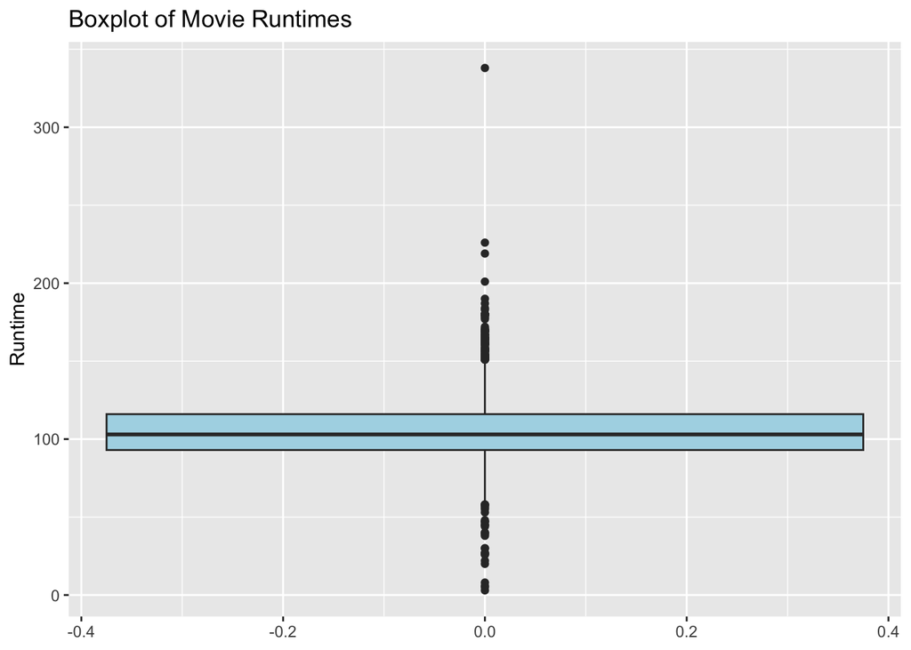

```r
ggplot(filtered_data, aes(y=Runtime)) + geom_boxplot(fill="lightblue") + ggtitle("Boxplot of Movie Runtimes")
```

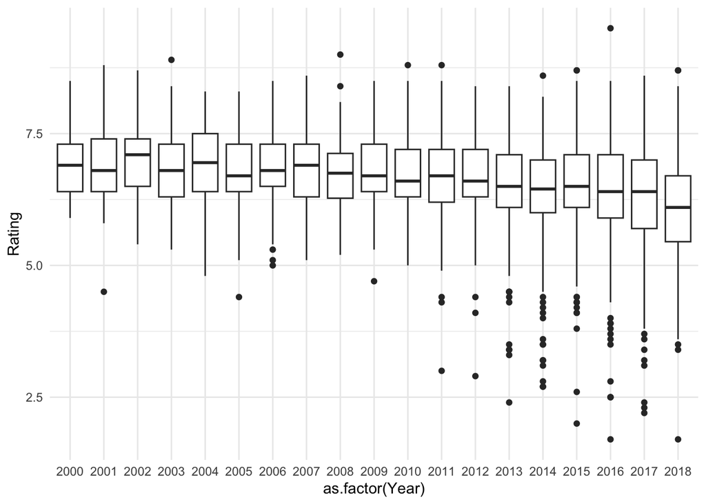

```r
ggplot(data, aes(x=as.factor(Year), y=Rating)) + geom_boxplot() + theme_minimal()
```

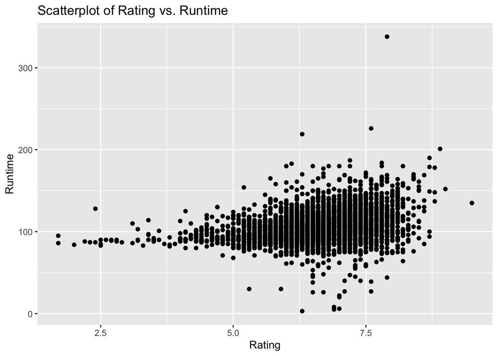

```r
ggplot(filtered_data, aes(x=Rating, y=Runtime)) + geom_point() + ggtitle("Scatterplot of Rating vs. Runtime")
```

[figure not shown]

```r
library(ggplot2)
library(dplyr)
summary_data <- data %>%
  group_by(Year) %>%
  summarise(Avg_Rating = mean(Rating, na.rm = TRUE))

ggplot(summary_data, aes(x = Year, y = 1, fill = Avg_Rating)) +
  geom_tile() +
  scale_fill_gradient(low = "blue", high = "red") +
  labs(fill = "Average Rating") +
  theme_minimal() +
  ylab("") +
  coord_fixed(ratio = 0.2)
```

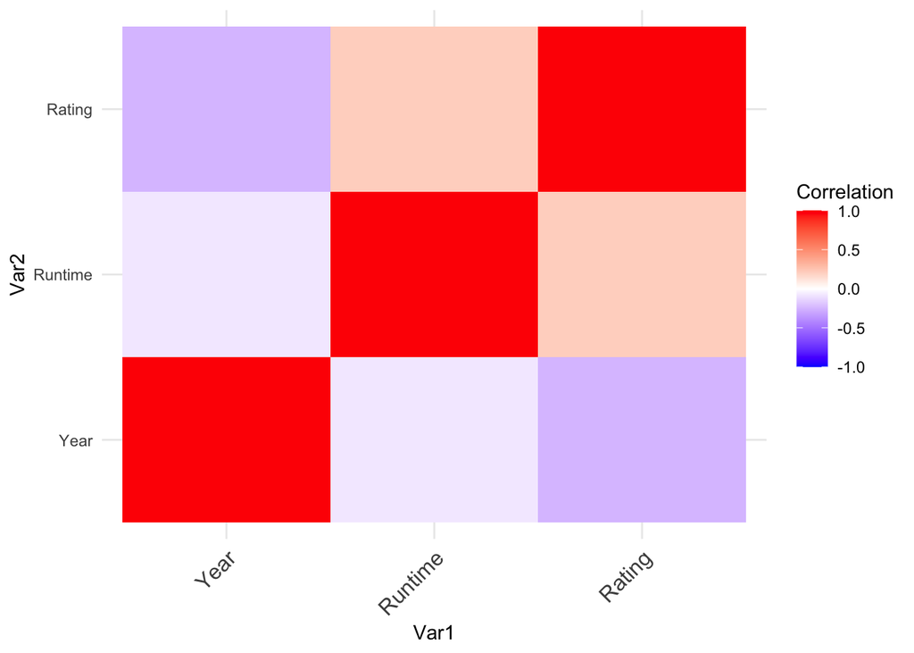

```r
library(reshape2)

melted_cor_matrix <- melt(cor_matrix)
ggplot(data = melted_cor_matrix, aes(x=Var1, y=Var2, fill=value)) +
  geom_tile() +
  scale_fill_gradient2(low = "blue", high = "red", mid = "white",
                       midpoint = 0, limit = c(-1,1), name="Correlation") +
  theme_minimal() +
  theme(axis.text.x = element_text(angle = 45, vjust = 1, size = 12, hjust = 1))
```

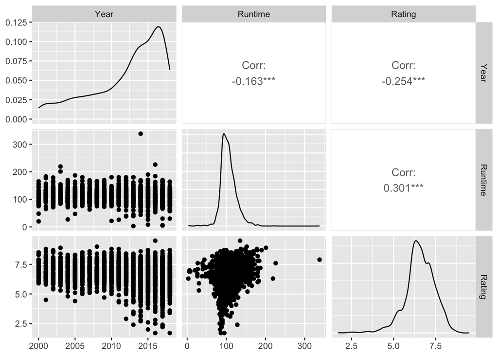

```r
library(ggplot2)
library(GGally)
data <- data[data$Runtime != 0,]

cor_matrix <- cor(data[,c('Year', 'Runtime', 'Rating')], use="complete.obs")

ggpairs(data, columns=c('Year', 'Runtime', 'Rating'))
```

```r
summary(data[c('Year', 'Runtime', 'Rating')])
```

```
      Year         Runtime          Rating
 Min.   :2000   Min.   :  3.0   Min.   :1.700
 1st Qu.:2009   1st Qu.: 93.0   1st Qu.:6.100
 Median :2014   Median :103.0   Median :6.600
 Mean   :2012   Mean   :105.5   Mean   :6.561
 3rd Qu.:2016   3rd Qu.:116.0   3rd Qu.:7.100
 Max.   :2018   Max.   :338.0   Max.   :9.500
```

5.

Hypothesis:

1. has the average length of movies changed over the past few decades?

2. do longer movies usually receive higher ratings?

3. has the average rating of movies increased over time?

```r
data_filter <- data[data$Runtime != 0,]


data_filter$RatingGroup <- cut(data_filter$Rating,
                               breaks = c(0, 6, 8, 10),
                               labels = c("Low", "Medium", "High"),
                               include.lowest = TRUE, right = TRUE)

grouped_data <- data_filter %>%
  group_by(RatingGroup) %>%
  summarise(Count = n(),
            AverageRuntime = mean(Runtime, na.rm = TRUE))


print(grouped_data)
```

```
# A tibble: 3 × 3
  RatingGroup Count AverageRuntime
  <fct>       <int>          <dbl>
1 Low           843           98.4
2 Medium       2781          107.
3 High          123          123.
```

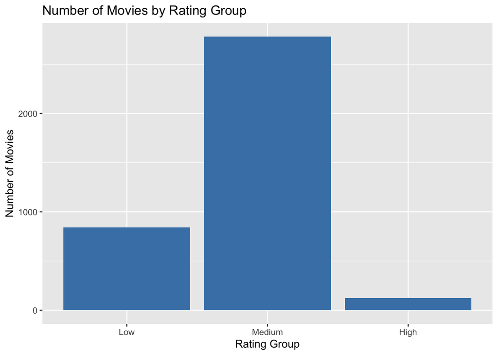

```r
ggplot(grouped_data, aes(x = RatingGroup, y = Count)) +
  geom_bar(stat = "identity", fill = "steelblue") +
  labs(title = "Number of Movies by Rating Group",
       x = "Rating Group",
       y = "Number of Movies")
```

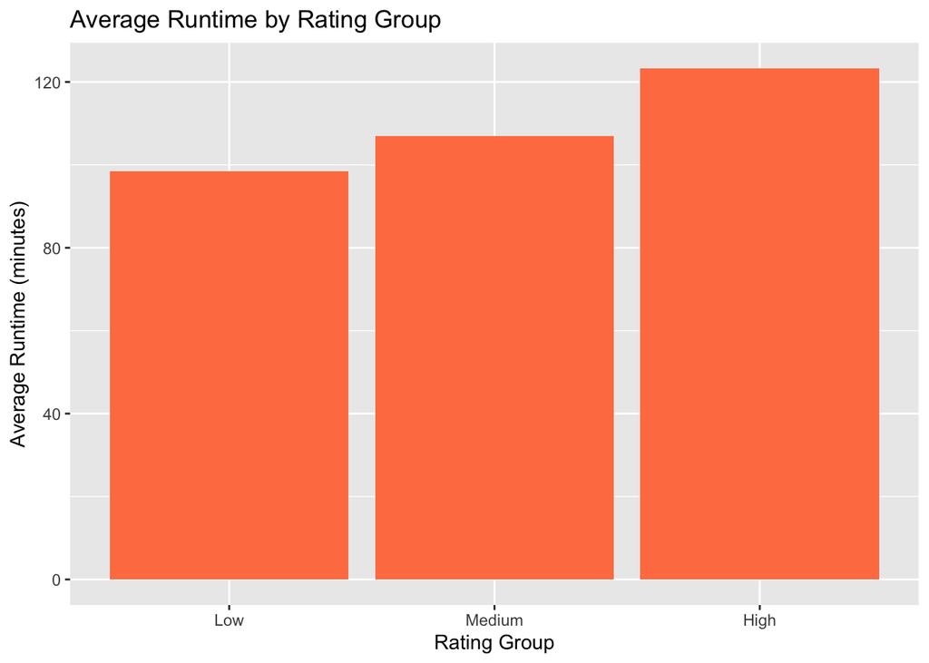

```r
ggplot(grouped_data, aes(x = RatingGroup, y = AverageRuntime)) +
  geom_bar(stat = "identity", fill = "coral") +
  labs(title = "Average Runtime by Rating Group",
       x = "Rating Group",
       y = "Average Runtime (minutes)")
```

7.Some movies show 0 hours.

**ANSWER for 8**

1. Methodology and tools

To perform this EDA we used R language and its libraries such as ggplot2 and dplyr. our methodology includes data summarization, data visualization, data transformation, grouping, and segmentation.

2. Key Findings

Data overview

The dataset consists of years of movie data, which contains fields such as title, year, summary, duration, rating, and director.

Examination of movie duration

For some movies, the duration was recorded as 0. This could be a result of missing data or an entry error. To ensure the accuracy of the analysis, we filtered out these movies from the dataset.

Rating Conversion

Rating Segmentation

Based on the ratings, we segmented the movies into three groups: low (0-6), medium (6-8), and high (8-10). This segmentation allows us to better understand the characteristics of movies in different rating ranges.

3. Insights and Patterns

Relationship between ratings and number of movies

The results show that most of the movies are concentrated in the medium rating group. This means that most of the movies received moderate ratings, while the number of high and low rated movies is relatively small.

Relationship between ratings and average duration

4. Graphical presentation

We used bar charts to show the number and average duration of movies in different rating groups. This helps to visualize the characteristics of movies in different rating groups.

5. Conclusion

EDA has provided us with an in-depth understanding of the movie dataset. While we found some interesting patterns, more in-depth analysis, such as considering other variables or using more sophisticated statistical methods, is needed to get a more comprehensive conclusion.

**ANSWER for 9**

ggplot2: This is one of the main data visualization libraries for R. It uses the concept of “syntax layers” to build graphs. This makes ggplot2 very flexible and capable of creating a wide variety of graphs. In your dataset, ggplot2 is used to show the distribution and relationships of your data.

GGally: This package provides extensions to ggplot2 that enable more complex graphs to be drawn, such as diagonal matrix plots. In your analysis, you used the ggpairs function to show the relationship between different columns.

base R functions: R’s base functions are used for data processing, such as conditional filtering. In your dataset, you used the base functions to filter out certain specific rows (e.g., rows with a movie duration of 0).